# ArviZ.jl Quickstart

Note

This tutorial is adapted from [ArviZ's quickstart](https://arviz-devs.github.io/arviz/getting_started/Introduction.html).

```julia
using ArviZ
using PyPlot

# ArviZ ships with style sheets!
ArviZ.use_style("arviz-darkgrid")
```

## Get started with plotting

ArviZ.jl is designed to be used with libraries like [CmdStan](https://github.com/StanJulia/CmdStan.jl), [Turing.jl](https://turing.ml), and Soss.jl but works fine with raw arrays.

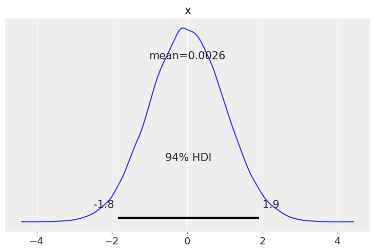

```julia
using Random

rng = Random.MersenneTwister(37772)
plot_posterior(randn(rng, 100_000));
gcf()
```

Plotting a dictionary of arrays, ArviZ.jl will interpret each key as the name of a different random variable. Each row of an array is treated as an independent series of draws from the variable, called a *chain*. Below, we have 10 chains of 50 draws each for four different distributions.

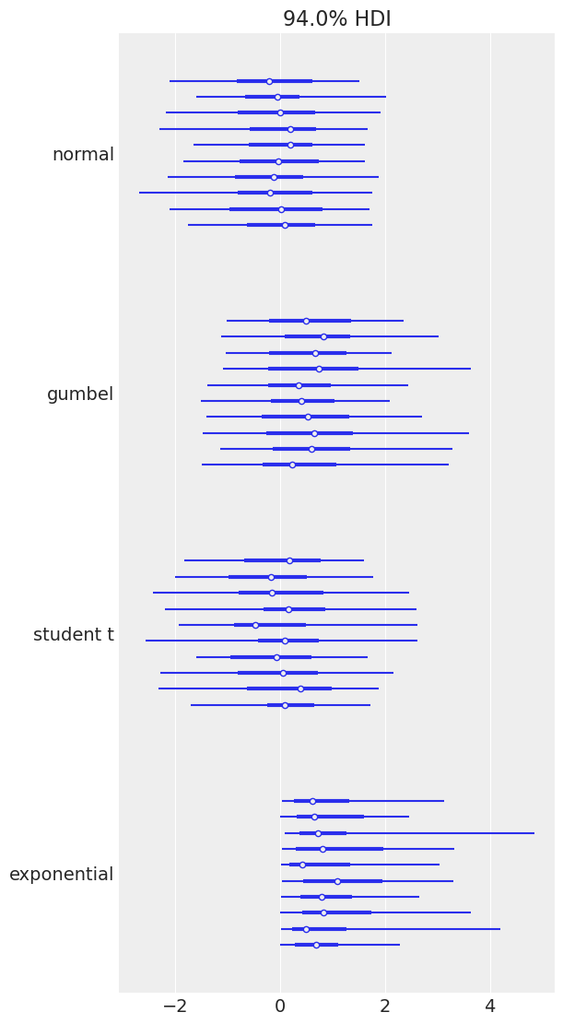

```julia
using Distributions

s = (10, 50)
plot_forest(
    Dict(
        "normal" => randn(rng, s),
        "gumbel" => rand(rng, Gumbel(), s),
        "student t" => rand(rng, TDist(6), s),
        "exponential" => rand(rng, Exponential(), s),
    ),
);
gcf()
```

## Plotting with MCMCChains.jl's `Chains` objects produced by Turing.jl

ArviZ is designed to work well with high dimensional, labelled data. Consider the [eight schools model](https://statmodeling.stat.columbia.edu/2014/01/21/everything-need-know-bayesian-statistics-learned-eight-schools/), which roughly tries to measure the effectiveness of SAT classes at eight different schools. To show off ArviZ's labelling, I give the schools the names of [a different eight schools](https://en.wikipedia.org/wiki/Eight_Schools_Association).

This model is small enough to write down, is hierarchical, and uses labelling. Additionally, a centered parameterization causes [divergences](https://mc-stan.org/users/documentation/case-studies/divergences_and_bias.html) (which are interesting for illustration).

First we create our data and set some sampling parameters.

```julia
J = 8
y = [28.0, 8.0, -3.0, 7.0, -1.0, 1.0, 18.0, 12.0]
σ = [15.0, 10.0, 16.0, 11.0, 9.0, 11.0, 10.0, 18.0]
schools = [
    "Choate",
    "Deerfield",
    "Phillips Andover",
    "Phillips Exeter",
    "Hotchkiss",
    "Lawrenceville",
    "St. Paul's",
    "Mt. Hermon",
];

nwarmup, nsamples, nchains = 1000, 1000, 4;
```

Now we write and run the model using Turing:

```julia
using Turing

Turing.@model function turing_model(y, σ, J=length(y))
    μ ~ Normal(0, 5)
    τ ~ truncated(Cauchy(0, 5), 0, Inf)
    θ ~ filldist(Normal(μ, τ), J)
    for i in 1:J
        y[i] ~ Normal(θ[i], σ[i])
    end
end

param_mod = turing_model(y, σ)
sampler = NUTS(nwarmup, 0.8)

rng = Random.MersenneTwister(16653)
turing_chns = sample(
    rng, param_mod, sampler, MCMCThreads(), nsamples, nchains; progress=false
);
```

```
┌ Info: Found initial step size
└   ϵ = 0.8
┌ Info: Found initial step size
└   ϵ = 0.8
┌ Info: Found initial step size
└   ϵ = 0.4
┌ Info: Found initial step size
└   ϵ = 0.4
```

Most ArviZ functions work fine with `Chains` objects from Turing:

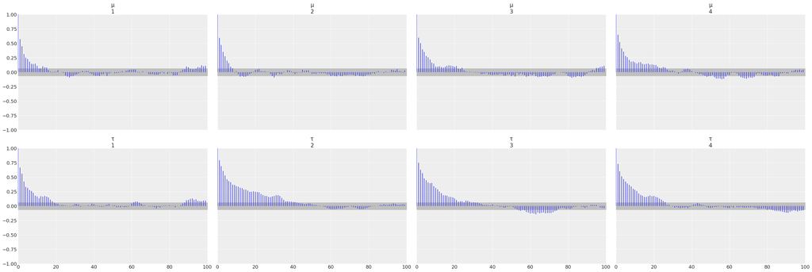

```julia
plot_autocorr(turing_chns; var_names=["μ", "τ"]);
gcf()
```

### Convert to `InferenceData`

For much more powerful querying, analysis and plotting, we can use built-in ArviZ utilities to convert `Chains` objects to xarray datasets. Note we are also giving some information about labelling.

ArviZ is built to work with `InferenceData` (a netcdf datastore that loads data into `xarray` datasets), and the more *groups* it has access to, the more powerful analyses it can perform.

```julia
idata = from_mcmcchains(
    turing_chns;
    coords=Dict("school" => schools),
    dims=Dict("y" => ["school"], "σ" => ["school"], "θ" => ["school"]),
    library="Turing",
)
```

InferenceData

- posterior

  ```
  Dataset (xarray.Dataset)
  Dimensions:  (chain: 4, draw: 1000, school: 8)
  Coordinates:
    * chain    (chain) int64 1 2 3 4
    * draw     (draw) int64 1 2 3 4 5 6 7 8 9 ... 993 994 995 996 997 998 999 1000
    * school   (school) <U16 'Choate' 'Deerfield' ... "St. Paul's" 'Mt. Hermon'
  Data variables:
      μ        (chain, draw) float64 2.165 -0.3012 -0.138 ... -1.124 -1.01 3.933
      τ        (chain, draw) float64 3.889 6.079 15.28 7.384 ... 6.474 5.583 4.12
      θ        (chain, draw, school) float64 3.638 3.869 2.71 ... 1.051 -0.513
  Attributes:
      created_at:         2022-03-23T19:47:16.380638
      arviz_version:      0.11.4
      start_time:         [1.64806479e+09 1.64806481e+09 1.64806479e+09 1.64806...
      stop_time:          [1.64806481e+09 1.64806482e+09 1.64806481e+09 1.64806...
      inference_library:  Turing
  ```

- sample_stats

  ```
  Dataset (xarray.Dataset)
  Dimensions:           (chain: 4, draw: 1000)
  Coordinates:
    * chain             (chain) int64 1 2 3 4
    * draw              (draw) int64 1 2 3 4 5 6 7 ... 995 996 997 998 999 1000
  Data variables:
      energy            (chain, draw) float64 61.6 62.57 69.19 ... 62.56 62.92
      energy_error      (chain, draw) float64 -0.0432 0.09601 ... 0.002727
      tree_depth        (chain, draw) int64 3 4 4 5 5 5 5 5 5 ... 4 4 4 5 5 5 5 5
      diverging         (chain, draw) bool False False False ... False False False
      step_size_nom     (chain, draw) float64 0.102 0.1489 ... 0.09994 0.09994
      acceptance_rate   (chain, draw) float64 0.9881 0.9158 ... 0.9961 0.9942
      log_density       (chain, draw) float64 -54.26 -58.95 ... -58.35 -56.61
      max_energy_error  (chain, draw) float64 0.1225 0.4607 ... -0.07489 -0.01799
      is_accept         (chain, draw) bool True True True True ... True True True
      lp                (chain, draw) float64 -54.26 -58.95 ... -58.35 -56.61
      step_size         (chain, draw) float64 0.102 0.1489 ... 0.09994 0.09994
      n_steps           (chain, draw) int64 15 15 31 31 31 31 ... 31 31 63 31 31
  Attributes:
      created_at:         2022-03-23T19:47:16.424689
      arviz_version:      0.11.4
      start_time:         [1.64806479e+09 1.64806481e+09 1.64806479e+09 1.64806...
      stop_time:          [1.64806481e+09 1.64806482e+09 1.64806481e+09 1.64806...
      inference_library:  Turing
  ```

Each group is an `ArviZ.Dataset` (a thinly wrapped `xarray.Dataset`). We can view a summary of the dataset.

```julia
idata.posterior
```

```
Dataset (xarray.Dataset)
Dimensions:  (chain: 4, draw: 1000, school: 8)
Coordinates:
  * chain    (chain) int64 1 2 3 4
  * draw     (draw) int64 1 2 3 4 5 6 7 8 9 ... 993 994 995 996 997 998 999 1000
  * school   (school) <U16 'Choate' 'Deerfield' ... "St. Paul's" 'Mt. Hermon'
Data variables:
    μ        (chain, draw) float64 2.165 -0.3012 -0.138 ... -1.124 -1.01 3.933
    τ        (chain, draw) float64 3.889 6.079 15.28 7.384 ... 6.474 5.583 4.12
    θ        (chain, draw, school) float64 3.638 3.869 2.71 ... 1.051 -0.513
Attributes:
    created_at:         2022-03-23T19:47:16.380638
    arviz_version:      0.11.4
    start_time:         [1.64806479e+09 1.64806481e+09 1.64806479e+09 1.64806...
    stop_time:          [1.64806481e+09 1.64806482e+09 1.64806481e+09 1.64806...
    inference_library:  Turing
```

Here is a plot of the trace. Note the intelligent labels.

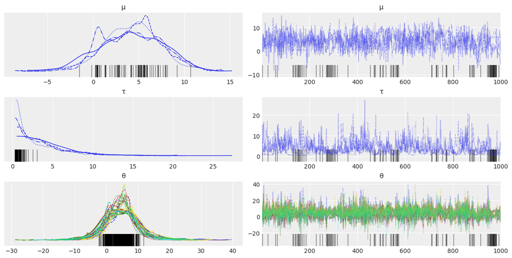

```julia
plot_trace(idata);
gcf()
```

We can also generate summary stats

```julia
summarystats(idata)
```

10 rows × 10 columns

|  | variable String | mean Float64 | sd Float64 | hdi_3% Float64 | hdi_97% Float64 | mcse_mean Float64 | mcse_sd Float64 | ess_bulk Float64 | ess_tail Float64 | r_hat Float64 |
| --- | --- | --- | --- | --- | --- | --- | --- | --- | --- | --- |
| 1 | μ | 4.235 | 3.263 | -1.413 | 10.621 | 0.148 | 0.104 | 491.0 | 856.0 | 1.01 |
| 2 | τ | 3.755 | 3.165 | 0.333 | 9.503 | 0.213 | 0.151 | 118.0 | 121.0 | 1.04 |
| 3 | θ[Choate] | 6.187 | 5.804 | -3.668 | 17.78 | 0.224 | 0.158 | 611.0 | 1193.0 | 1.01 |
| 4 | θ[Deerfield] | 4.721 | 4.746 | -4.62 | 13.317 | 0.164 | 0.116 | 762.0 | 1407.0 | 1.01 |
| 5 | θ[Phillips Andover] | 3.718 | 5.354 | -6.746 | 13.499 | 0.15 | 0.117 | 1142.0 | 1767.0 | 1.01 |
| 6 | θ[Phillips Exeter] | 4.597 | 4.838 | -4.601 | 13.64 | 0.149 | 0.105 | 883.0 | 2133.0 | 1.01 |
| 7 | θ[Hotchkiss] | 3.386 | 4.707 | -5.555 | 12.15 | 0.173 | 0.122 | 720.0 | 1532.0 | 1.01 |
| 8 | θ[Lawrenceville] | 3.825 | 5.014 | -6.466 | 12.812 | 0.155 | 0.118 | 920.0 | 1481.0 | 1.01 |
| 9 | θ[St. Paul's] | 6.284 | 5.14 | -3.243 | 16.11 | 0.21 | 0.148 | 539.0 | 1005.0 | 1.02 |
| 10 | θ[Mt. Hermon] | 4.836 | 5.533 | -6.323 | 15.335 | 0.167 | 0.125 | 891.0 | 1749.0 | 1.01 |

and examine the energy distribution of the Hamiltonian sampler

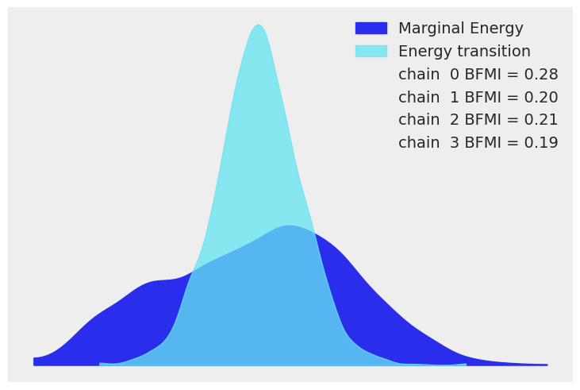

```julia
plot_energy(idata);
gcf()
```

### Additional information in Turing.jl

With a few more steps, we can use Turing to compute additional useful groups to add to the `InferenceData`.

To sample from the prior, one simply calls `sample` but with the `Prior` sampler:

```julia
prior = sample(param_mod, Prior(), nsamples; progress=false)
```

```
Chains MCMC chain (1000×11×1 Array{Float64, 3}):

Iterations        = 1:1:1000
Number of chains  = 1
Samples per chain = 1000
Wall duration     = 0.24 seconds
Compute duration  = 0.24 seconds
parameters        = μ, τ, θ[1], θ[2], θ[3], θ[4], θ[5], θ[6], θ[7], θ[8]
internals         = lp

Summary Statistics
  parameters       mean        std   naive_se      mcse         ess      rhat  ⋯
      Symbol    Float64    Float64    Float64   Float64     Float64   Float64  ⋯

           μ    -0.1630     5.0485     0.1596    0.1564    995.1996    0.9995  ⋯
           τ    27.0679   201.8740     6.3838    6.4204   1019.1986    1.0004  ⋯
        θ[1]    -2.9509   138.3289     4.3743    4.2848   1002.1640    0.9990  ⋯
        θ[2]    11.5049   361.1966    11.4220   11.4745    997.8672    1.0011  ⋯
        θ[3]    -1.1918    96.4676     3.0506    3.1809    974.3288    1.0001  ⋯
        θ[4]    -7.0842   173.2074     5.4773    5.4043   1003.7932    1.0000  ⋯
        θ[5]    -2.0057   139.3471     4.4065    4.6055   1002.5990    0.9994  ⋯
        θ[6]   -15.5094   371.4045    11.7448   11.5480   1005.1151    0.9999  ⋯
        θ[7]     2.3834    93.1624     2.9461    2.9584   1012.7390    0.9994  ⋯
        θ[8]    -3.4488   174.4119     5.5154    6.5047   1005.0799    1.0000  ⋯
                                                                1 column omitted

Quantiles
  parameters       2.5%     25.0%     50.0%     75.0%      97.5%
      Symbol    Float64   Float64   Float64   Float64    Float64

           μ   -10.3705   -3.4304   -0.2244    3.4585     9.0804
           τ     0.1913    2.1629    5.2454   12.3578   126.8830
        θ[1]   -57.5462   -6.5415   -0.4276    5.0619    50.9764
        θ[2]   -52.6378   -6.2558   -0.3323    5.1001    53.0439
        θ[3]   -43.2108   -6.0958   -0.3865    5.0226    59.0231
        θ[4]   -58.4217   -6.3853   -0.3348    5.4302    52.6397
        θ[5]   -42.8578   -6.2208   -0.1947    5.5147    65.1893
        θ[6]   -51.1761   -5.9628   -0.3197    5.7019    43.0682
        θ[7]   -52.0363   -6.2582   -0.2994    5.4029    48.9369
        θ[8]   -48.8366   -5.2361    0.3672    5.9881    45.6908
```

To draw from the prior and posterior predictive distributions we can instantiate a "predictive model", i.e. a Turing model but with the observations set to `missing`, and then calling `predict` on the predictive model and the previously drawn samples:

```julia
# Instantiate the predictive model
param_mod_predict = turing_model(similar(y, Missing), σ)
# and then sample!
prior_predictive = predict(param_mod_predict, prior)
posterior_predictive = predict(param_mod_predict, turing_chns)
```

```
Chains MCMC chain (1000×8×4 Array{Float64, 3}):

Iterations        = 1:1:1000
Number of chains  = 4
Samples per chain = 1000
parameters        = y[1], y[2], y[3], y[4], y[5], y[6], y[7], y[8]
internals         =

Summary Statistics
  parameters      mean       std   naive_se      mcse         ess      rhat
      Symbol   Float64   Float64    Float64   Float64     Float64   Float64

        y[1]    6.5230   16.0976     0.2545    0.3167   2554.0966    1.0001
        y[2]    4.8312   11.0850     0.1753    0.2303   2657.5551    1.0004
        y[3]    3.6590   16.7104     0.2642    0.2263   3318.6709    1.0000
        y[4]    4.3379   12.3016     0.1945    0.2031   3321.8857    0.9993
        y[5]    3.6242   10.1612     0.1607    0.2544   2108.9713    1.0014
        y[6]    3.8064   12.1507     0.1921    0.2539   2783.4672    0.9994
        y[7]    6.1250   11.2946     0.1786    0.2846   1918.3163    1.0000
        y[8]    4.9759   18.8026     0.2973    0.3779   3566.0375    1.0001

Quantiles
  parameters       2.5%     25.0%     50.0%     75.0%     97.5%
      Symbol    Float64   Float64   Float64   Float64   Float64

        y[1]   -25.3217   -4.1006    6.4160   17.1595   38.6448
        y[2]   -16.8604   -2.3641    4.7375   12.2424   26.3203
        y[3]   -29.9630   -7.4976    3.9970   14.9172   36.7844
        y[4]   -20.2201   -3.6806    4.5217   12.3731   27.8408
        y[5]   -16.0692   -3.4183    3.6788   10.4950   23.0982
        y[6]   -20.7985   -4.0141    3.8035   11.8140   27.8440
        y[7]   -15.7422   -1.3319    5.9418   13.2375   29.0848
        y[8]   -30.6572   -7.9583    5.0985   17.3031   41.9114
```

And to extract the pointwise log-likelihoods, which is useful if you want to compute metrics such as `loo`,

```julia
loglikelihoods = Turing.pointwise_loglikelihoods(
    param_mod, MCMCChains.get_sections(turing_chns, :parameters)
)
```

```
Dict{String, Matrix{Float64}} with 8 entries:
  "y[6]" => [-3.31769 -3.3407 -3.66535 -3.31789; -3.64727 -3.3407 -3.40345 -3.3…
  "y[2]" => [-3.30683 -3.31533 -3.23247 -3.34744; -3.58999 -3.31533 -3.22211 -3…
  "y[1]" => [-4.94586 -4.99174 -5.64838 -5.16878; -4.91325 -4.99174 -6.10856 -5…
  "y[5]" => [-3.42208 -3.21396 -3.12175 -3.1831; -3.26773 -3.21396 -3.14939 -3.…
  "y[8]" => [-4.09697 -3.93589 -3.90201 -4.01375; -3.87055 -3.93589 -3.84957 -3…
  "y[7]" => [-3.73706 -4.36987 -3.26904 -4.25333; -4.11982 -4.36987 -3.29001 -4…
  "y[3]" => [-3.7552 -3.75946 -3.71716 -3.80203; -3.6924 -3.75946 -3.72663 -3.7…
  "y[4]" => [-3.36883 -3.35918 -3.43424 -3.43025; -3.47259 -3.35918 -3.32614 -3…
```

This can then be included in the `from_mcmcchains` call from above:

```julia
using LinearAlgebra
# Ensure the ordering of the loglikelihoods matches the ordering of `posterior_predictive`
ynames = string.(keys(posterior_predictive))
loglikelihoods_vals = getindex.(Ref(loglikelihoods), ynames)
# Reshape into `(nchains, nsamples, size(y)...)`
loglikelihoods_arr = permutedims(cat(loglikelihoods_vals...; dims=3), (2, 1, 3))

idata = from_mcmcchains(
    turing_chns;
    posterior_predictive=posterior_predictive,
    log_likelihood=Dict("y" => loglikelihoods_arr),
    prior=prior,
    prior_predictive=prior_predictive,
    observed_data=Dict("y" => y),
    coords=Dict("school" => schools),
    dims=Dict("y" => ["school"], "σ" => ["school"], "θ" => ["school"]),
    library="Turing",
)
```

InferenceData

- posterior

  ```
  Dataset (xarray.Dataset)
  Dimensions:  (chain: 4, draw: 1000, school: 8)
  Coordinates:
    * chain    (chain) int64 1 2 3 4
    * draw     (draw) int64 1 2 3 4 5 6 7 8 9 ... 993 994 995 996 997 998 999 1000
    * school   (school) <U16 'Choate' 'Deerfield' ... "St. Paul's" 'Mt. Hermon'
  Data variables:
      μ        (chain, draw) float64 2.165 -0.3012 -0.138 ... -1.124 -1.01 3.933
      τ        (chain, draw) float64 3.889 6.079 15.28 7.384 ... 6.474 5.583 4.12
      θ        (chain, draw, school) float64 3.638 3.869 2.71 ... 1.051 -0.513
  Attributes:
      created_at:         2022-03-23T19:48:00.638727
      arviz_version:      0.11.4
      start_time:         [1.64806479e+09 1.64806481e+09 1.64806479e+09 1.64806...
      stop_time:          [1.64806481e+09 1.64806482e+09 1.64806481e+09 1.64806...
      inference_library:  Turing
  ```

- posterior_predictive

  ```
  Dataset (xarray.Dataset)
  Dimensions:  (chain: 4, draw: 1000, school: 8)
  Coordinates:
    * chain    (chain) int64 1 2 3 4
    * draw     (draw) int64 1 2 3 4 5 6 7 8 9 ... 993 994 995 996 997 998 999 1000
    * school   (school) <U16 'Choate' 'Deerfield' ... "St. Paul's" 'Mt. Hermon'
  Data variables:
      y        (chain, draw, school) float64 -17.58 -5.268 6.1 ... 15.81 -8.556
  Attributes:
      start_time:         [None, None, None, None]
      created_at:         2022-03-23T19:47:59.883925
      stop_time:          [None, None, None, None]
      arviz_version:      0.11.4
      inference_library:  Turing
  ```

- log_likelihood

  ```
  Dataset (xarray.Dataset)
  Dimensions:  (chain: 4, draw: 1000, school: 8)
  Coordinates:
    * chain    (chain) int64 1 2 3 4
    * draw     (draw) int64 1 2 3 4 5 6 7 8 9 ... 993 994 995 996 997 998 999 1000
    * school   (school) <U16 'Choate' 'Deerfield' ... "St. Paul's" 'Mt. Hermon'
  Data variables:
      y        (chain, draw, school) float64 -4.946 -3.307 ... -4.658 -4.051
  Attributes:
      created_at:         2022-03-23T19:48:00.529872
      arviz_version:      0.11.4
      inference_library:  Turing
  ```

- sample_stats

  ```
  Dataset (xarray.Dataset)
  Dimensions:           (chain: 4, draw: 1000)
  Coordinates:
    * chain             (chain) int64 1 2 3 4
    * draw              (draw) int64 1 2 3 4 5 6 7 ... 995 996 997 998 999 1000
  Data variables:
      energy            (chain, draw) float64 61.6 62.57 69.19 ... 62.56 62.92
      energy_error      (chain, draw) float64 -0.0432 0.09601 ... 0.002727
      tree_depth        (chain, draw) int64 3 4 4 5 5 5 5 5 5 ... 4 4 4 5 5 5 5 5
      diverging         (chain, draw) bool False False False ... False False False
      step_size_nom     (chain, draw) float64 0.102 0.1489 ... 0.09994 0.09994
      acceptance_rate   (chain, draw) float64 0.9881 0.9158 ... 0.9961 0.9942
      log_density       (chain, draw) float64 -54.26 -58.95 ... -58.35 -56.61
      max_energy_error  (chain, draw) float64 0.1225 0.4607 ... -0.07489 -0.01799
      is_accept         (chain, draw) bool True True True True ... True True True
      lp                (chain, draw) float64 -54.26 -58.95 ... -58.35 -56.61
      step_size         (chain, draw) float64 0.102 0.1489 ... 0.09994 0.09994
      n_steps           (chain, draw) int64 15 15 31 31 31 31 ... 31 31 63 31 31
  Attributes:
      created_at:         2022-03-23T19:48:00.645257
      arviz_version:      0.11.4
      start_time:         [1.64806479e+09 1.64806481e+09 1.64806479e+09 1.64806...
      stop_time:          [1.64806481e+09 1.64806482e+09 1.64806481e+09 1.64806...
      inference_library:  Turing
  ```

- prior

  ```
  Dataset (xarray.Dataset)
  Dimensions:  (chain: 1, draw: 1000, school: 8)
  Coordinates:
    * chain    (chain) int64 1
    * draw     (draw) int64 1 2 3 4 5 6 7 8 9 ... 993 994 995 996 997 998 999 1000
    * school   (school) <U16 'Choate' 'Deerfield' ... "St. Paul's" 'Mt. Hermon'
  Data variables:
      μ        (chain, draw) float64 4.568 -2.567 0.4837 ... -1.122 -10.76
      τ        (chain, draw) float64 2.16 20.37 27.35 3.063 ... 30.93 2.363 5.273
      θ        (chain, draw, school) float64 6.59 9.79 3.426 ... -11.28 -14.81
  Attributes:
      created_at:         2022-03-23T19:48:02.568520
      arviz_version:      0.11.4
      start_time:         1648064847.417489
      stop_time:          1648064847.660955
      inference_library:  Turing
  ```

- prior_predictive

  ```
  Dataset (xarray.Dataset)
  Dimensions:  (chain: 1, draw: 1000, school: 8)
  Coordinates:
    * chain    (chain) int64 1
    * draw     (draw) int64 1 2 3 4 5 6 7 8 9 ... 993 994 995 996 997 998 999 1000
    * school   (school) <U16 'Choate' 'Deerfield' ... "St. Paul's" 'Mt. Hermon'
  Data variables:
      y        (chain, draw, school) float64 14.52 14.0 3.646 ... 7.222 -12.87
  Attributes:
      created_at:         2022-03-23T19:48:02.429448
      arviz_version:      0.11.4
      inference_library:  Turing
  ```

- sample_stats_prior

  ```
  Dataset (xarray.Dataset)
  Dimensions:  (chain: 1, draw: 1000)
  Coordinates:
    * chain    (chain) int64 1
    * draw     (draw) int64 1 2 3 4 5 6 7 8 9 ... 993 994 995 996 997 998 999 1000
  Data variables:
      lp       (chain, draw) float64 -52.63 -91.45 -111.6 ... -86.68 -53.52 -72.1
  Attributes:
      created_at:         2022-03-23T19:48:02.603907
      arviz_version:      0.11.4
      start_time:         1648064847.417489
      stop_time:          1648064847.660955
      inference_library:  Turing
  ```

- observed_data

  ```
  Dataset (xarray.Dataset)
  Dimensions:  (school: 8)
  Coordinates:
    * school   (school) <U16 'Choate' 'Deerfield' ... "St. Paul's" 'Mt. Hermon'
  Data variables:
      y        (school) float64 28.0 8.0 -3.0 7.0 -1.0 1.0 18.0 12.0
  Attributes:
      created_at:         2022-03-23T19:48:04.033638
      arviz_version:      0.11.4
      inference_library:  Turing
  ```

```julia
loo(idata) # higher is better
```

1 rows × 7 columns

|  | loo Float64 | loo_se Float64 | p_loo Float64 | n_samples Int64 | n_data_points Int64 | warning Bool | loo_scale String |
| --- | --- | --- | --- | --- | --- | --- | --- |
| 1 | -30.7302 | 1.36495 | 0.873883 | 4000 | 8 | 0 | log |

If the model is well-calibrated, i.e. it replicates the true generative process well, the CDF of the pointwise LOO values should be similarly distributed to a uniform distribution. This can be inspected visually:

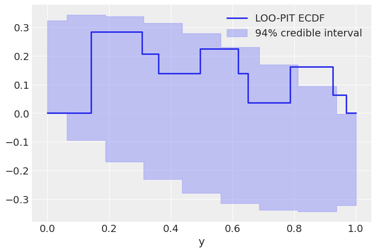

```julia
plot_loo_pit(idata; y="y", ecdf=true);
gcf()
```

## Plotting with CmdStan.jl outputs

CmdStan.jl and StanSample.jl also default to producing `Chains` outputs, and we can easily plot these chains.

Here is the same centered eight schools model:

```julia
using CmdStan, MCMCChains

schools_code = """
data {
  int<lower=0> J;
  real y[J];
  real<lower=0> sigma[J];
}

parameters {
  real mu;
  real<lower=0> tau;
  real theta[J];
}

model {
  mu ~ normal(0, 5);
  tau ~ cauchy(0, 5);
  theta ~ normal(mu, tau);
  y ~ normal(theta, sigma);
}

generated quantities {
    vector[J] log_lik;
    vector[J] y_hat;
    for (j in 1:J) {
        log_lik[j] = normal_lpdf(y[j] | theta[j], sigma[j]);
        y_hat[j] = normal_rng(theta[j], sigma[j]);
    }
}
"""

schools_dat = Dict("J" => J, "y" => y, "sigma" => σ)
stan_model = Stanmodel(;
    model=schools_code,
    name="schools",
    nchains=nchains,
    num_warmup=nwarmup,
    num_samples=nsamples,
    output_format=:mcmcchains,
    random=CmdStan.Random(28983),
)
_, stan_chns, _ = stan(stan_model, schools_dat; summary=false);
```

```
File /home/runner/work/ArviZ.jl/ArviZ.jl/docs/build/tmp/schools.stan will be updated.
```

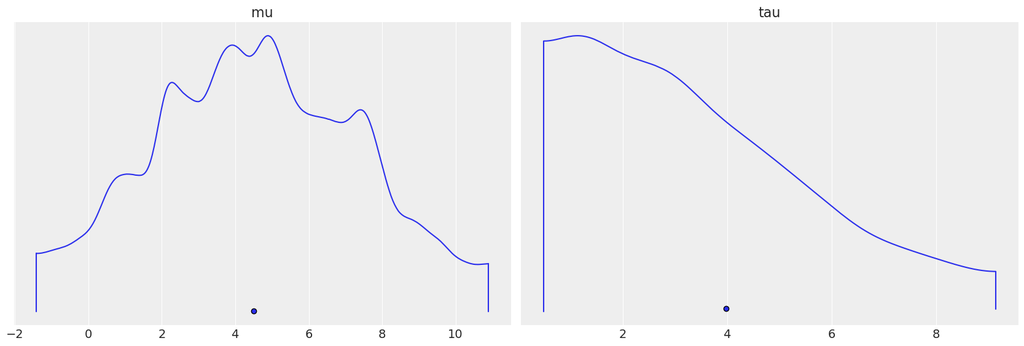

```julia
plot_density(stan_chns; var_names=["mu", "tau"]);
gcf()
```

Again, converting to `InferenceData`, we can get much richer labelling and mixing of data. Note that we're using the same `from_cmdstan` function used by ArviZ to process cmdstan output files, but through the power of dispatch in Julia, if we pass a `Chains` object, it instead uses ArviZ.jl's overloads, which forward to `from_mcmcchains`.

```julia
idata = from_cmdstan(
    stan_chns;
    posterior_predictive="y_hat",
    observed_data=Dict("y" => schools_dat["y"]),
    log_likelihood="log_lik",
    coords=Dict("school" => schools),
    dims=Dict(
        "y" => ["school"],
        "sigma" => ["school"],
        "theta" => ["school"],
        "log_lik" => ["school"],
        "y_hat" => ["school"],
    ),
)
```

InferenceData

- posterior

  ```
  Dataset (xarray.Dataset)
  Dimensions:  (chain: 4, draw: 1000, school: 8)
  Coordinates:
    * chain    (chain) int64 1 2 3 4
    * draw     (draw) int64 1 2 3 4 5 6 7 8 9 ... 993 994 995 996 997 998 999 1000
    * school   (school) <U16 'Choate' 'Deerfield' ... "St. Paul's" 'Mt. Hermon'
  Data variables:
      theta    (chain, draw, school) float64 6.541 4.165 1.673 ... 7.588 7.146
      tau      (chain, draw) float64 2.026 3.44 2.047 ... 0.5002 0.5771 0.5771
      mu       (chain, draw) float64 5.864 4.849 3.906 5.24 ... 7.369 7.617 7.617
  Attributes:
      created_at:         2022-03-23T19:48:56.139717
      arviz_version:      0.11.4
      inference_library:  CmdStan
  ```

- posterior_predictive

  ```
  Dataset (xarray.Dataset)
  Dimensions:  (chain: 4, draw: 1000, school: 8)
  Coordinates:
    * chain    (chain) int64 1 2 3 4
    * draw     (draw) int64 1 2 3 4 5 6 7 8 9 ... 993 994 995 996 997 998 999 1000
    * school   (school) <U16 'Choate' 'Deerfield' ... "St. Paul's" 'Mt. Hermon'
  Data variables:
      y_hat    (chain, draw, school) float64 -10.71 23.66 -9.425 ... 9.078 20.88
  Attributes:
      created_at:         2022-03-23T19:48:56.105753
      arviz_version:      0.11.4
      inference_library:  CmdStan
  ```

- log_likelihood

  ```
  Dataset (xarray.Dataset)
  Dimensions:  (chain: 4, draw: 1000, school: 8)
  Coordinates:
    * chain    (chain) int64 1 2 3 4
    * draw     (draw) int64 1 2 3 4 5 6 7 8 9 ... 993 994 995 996 997 998 999 1000
    * school   (school) <U16 'Choate' 'Deerfield' ... "St. Paul's" 'Mt. Hermon'
  Data variables:
      log_lik  (chain, draw, school) float64 -4.65 -3.295 -3.734 ... -3.764 -3.846
  Attributes:
      created_at:         2022-03-23T19:48:56.116404
      arviz_version:      0.11.4
      inference_library:  CmdStan
  ```

- sample_stats

  ```
  Dataset (xarray.Dataset)
  Dimensions:          (chain: 4, draw: 1000)
  Coordinates:
    * chain            (chain) int64 1 2 3 4
    * draw             (draw) int64 1 2 3 4 5 6 7 ... 994 995 996 997 998 999 1000
  Data variables:
      tree_depth       (chain, draw) int64 4 2 4 3 3 3 4 4 4 ... 1 1 2 1 2 1 5 3 2
      diverging        (chain, draw) bool False False False ... False True False
      energy           (chain, draw) float64 21.85 17.36 18.12 ... 11.01 16.54
      lp               (chain, draw) float64 -11.6 -14.53 -12.58 ... -6.09 -6.09
      step_size        (chain, draw) float64 0.2012 0.2012 ... 0.1493 0.1493
      acceptance_rate  (chain, draw) float64 0.9582 0.8976 ... 0.04874 1.587e-05
      n_steps          (chain, draw) int64 15 7 15 15 7 15 15 ... 5 1 5 3 31 9 3
  Attributes:
      created_at:         2022-03-23T19:48:56.154571
      arviz_version:      0.11.4
      inference_library:  CmdStan
  ```

- observed_data

  ```
  Dataset (xarray.Dataset)
  Dimensions:  (school: 8)
  Coordinates:
    * school   (school) <U16 'Choate' 'Deerfield' ... "St. Paul's" 'Mt. Hermon'
  Data variables:
      y        (school) float64 28.0 8.0 -3.0 7.0 -1.0 1.0 18.0 12.0
  Attributes:
      created_at:         2022-03-23T19:48:56.180015
      arviz_version:      0.11.4
      inference_library:  CmdStan
  ```

Here is a plot showing where the Hamiltonian sampler had divergences:

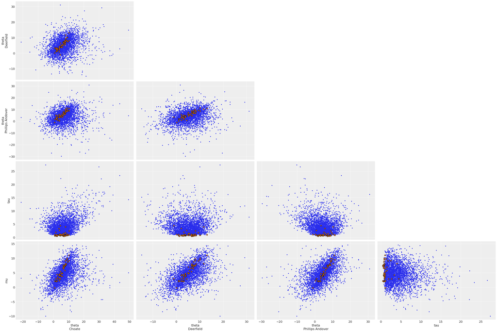

```julia
plot_pair(
    idata;
    coords=Dict("school" => ["Choate", "Deerfield", "Phillips Andover"]),
    divergences=true,
);
gcf()
```

## Plotting with Soss.jl outputs

With Soss, we can define our model for the posterior and easily use it to draw samples from the prior, prior predictive, posterior, and posterior predictive distributions.

First we define our model:

```julia
using Soss
using Soss.MeasureTheory: HalfCauchy, Normal

mod = Soss.@model (J, σ) begin
    μ ~ Normal(μ=0, σ=5)
    τ ~ HalfCauchy(σ=5)
    θ ~ Normal(μ=μ, σ=τ) |> iid(J)
    y ~ For(1:J) do j
        Normal(μ=θ[j], σ=σ[j])
    end
end

constant_data = (J=J, σ=σ)
observed_data = (y=y,)
param_mod = mod(; constant_data...)
```

```
ConditionalModel given
    arguments    (:J, :σ)
    observations ()
@model (J, σ) begin
        τ ~ HalfCauchy(σ = 5)
        μ ~ Normal(μ = 0, σ = 5)
        θ ~ Normal(μ = μ, σ = τ) |> iid(J)
        y ~ For(1:J) do j
                Normal(μ = θ[j], σ = σ[j])
            end
    end
```

Then we draw from the prior and prior predictive distributions.

```julia
rng = Random.seed!(5298)
prior_priorpred = [rand(rng, param_mod, nsamples) for _ in 1:nchains];
```

Soss returns predictive samples in a `TupleVector`, which is an efficient way of storing a vector of `NamedTuple`s. Next, we draw from the posterior using SampleChainsDynamicHMC.jl.

```julia
using SampleChainsDynamicHMC: getchains, dynamichmc
post = Soss.sample(rng, param_mod | observed_data, dynamichmc(), nsamples, nchains)
```

```
4000-element MultiChain with 4 chains and schema (τ = Float64, μ = Float64, θ = Vector{Float64})
(τ = 4.12±3.3, μ = 3.9±3.5, θ = [6.1±6.3, 4.5±4.9, 3.3±5.8, 4.3±5.0, 3.0±4.9, 3.5±5.0, 6.0±5.6, 4.5±5.8])
```

Soss returns posterior samples in a `SampleChains.AbstractChain` or, for multiple chains, in a `SampleChains.MultiChain`. Finally, we update the posterior samples with draws from the posterior predictive distribution.

```julia
mod_pred = Soss.predictive(mod, :μ, :τ, :θ)
postpred = map(getchains(post)) do chain
    [rand(rng, mod_pred(; constant_data..., draw...)) for draw in chain]
end;
```

We can plot the rank order statistics of the posterior to identify poor convergence:

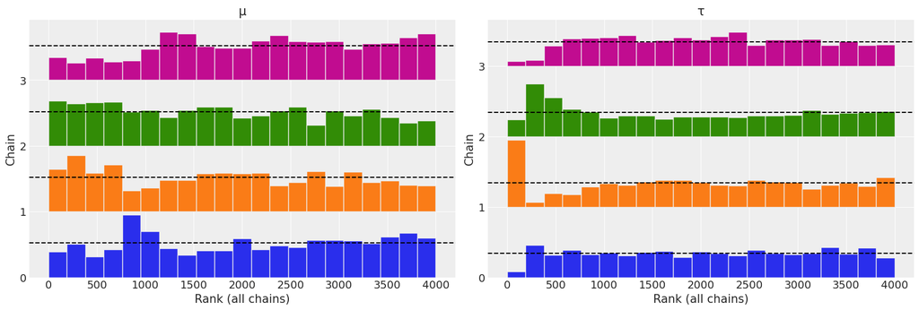

```julia
plot_rank(post; var_names=["μ", "τ"]);
gcf()
```

Now we combine all of the samples to an `InferenceData`:

```julia
idata = from_samplechains(
    post;
    posterior_predictive=postpred,
    prior=prior_priorpred,
    prior_predictive=[:y],
    observed_data=observed_data,
    constant_data=constant_data,
    coords=Dict("school" => schools),
    dims=Dict("y" => ["school"], "σ" => ["school"], "θ" => ["school"]),
    library=Soss,
)
```

InferenceData

- posterior

  ```
  Dataset (xarray.Dataset)
  Dimensions:  (chain: 4, draw: 1000, school: 8)
  Coordinates:
    * chain    (chain) int64 1 2 3 4
    * draw     (draw) int64 1 2 3 4 5 6 7 8 9 ... 993 994 995 996 997 998 999 1000
    * school   (school) <U16 'Choate' 'Deerfield' ... "St. Paul's" 'Mt. Hermon'
  Data variables:
      μ        (chain, draw) float64 3.614 -0.3743 5.83 ... 9.667 13.16 11.87
      τ        (chain, draw) float64 6.275 9.812 13.3 7.332 ... 1.794 2.85 2.915
      θ        (chain, draw, school) float64 12.16 12.88 -1.807 ... 11.49 9.676
  Attributes:
      created_at:         2022-03-23T19:50:58.480932
      arviz_version:      0.11.4
      inference_library:  Soss
  ```

- posterior_predictive

  ```
  Dataset (xarray.Dataset)
  Dimensions:  (chain: 4, draw: 1000, school: 8)
  Coordinates:
    * chain    (chain) int64 1 2 3 4
    * draw     (draw) int64 1 2 3 4 5 6 7 8 9 ... 993 994 995 996 997 998 999 1000
    * school   (school) <U16 'Choate' 'Deerfield' ... "St. Paul's" 'Mt. Hermon'
  Data variables:
      y        (chain, draw, school) float64 23.9 16.63 32.31 ... 8.165 30.42
  Attributes:
      created_at:         2022-03-23T19:50:58.259356
      arviz_version:      0.11.4
      inference_library:  Soss
  ```

- sample_stats

  ```
  Dataset (xarray.Dataset)
  Dimensions:          (chain: 4, draw: 1000)
  Coordinates:
    * chain            (chain) int64 1 2 3 4
    * draw             (draw) int64 1 2 3 4 5 6 7 ... 994 995 996 997 998 999 1000
  Data variables:
      acceptance_rate  (chain, draw) float64 0.9776 0.9998 ... 0.8539 0.9846
      n_steps          (chain, draw) int64 31 15 31 31 31 31 7 ... 23 7 7 7 15 15
      energy           (chain, draw) float64 -64.92 -64.48 -68.66 ... -58.2 -59.89
      diverging        (chain, draw) bool False False False ... False False False
      tree_depth       (chain, draw) int64 4 4 5 5 5 4 3 3 3 ... 3 3 3 4 2 3 3 4 4
      turning          (chain, draw) bool True True True True ... True True True
  Attributes:
      created_at:         2022-03-23T19:50:58.464880
      arviz_version:      0.11.4
      inference_library:  Soss
  ```

- prior

  ```
  Dataset (xarray.Dataset)
  Dimensions:  (chain: 4, draw: 1000, school: 8)
  Coordinates:
    * chain    (chain) int64 1 2 3 4
    * draw     (draw) int64 1 2 3 4 5 6 7 8 9 ... 993 994 995 996 997 998 999 1000
    * school   (school) <U16 'Choate' 'Deerfield' ... "St. Paul's" 'Mt. Hermon'
  Data variables:
      μ        (chain, draw) float64 -0.3472 1.656 1.989 ... -1.18 1.115 -0.1622
      τ        (chain, draw) float64 69.32 2.635 10.69 48.21 ... 9.276 7.364 3.033
      θ        (chain, draw, school) float64 -81.26 16.18 22.4 ... 1.745 -5.203
  Attributes:
      created_at:         2022-03-23T19:50:59.413307
      arviz_version:      0.11.4
      inference_library:  Soss
  ```

- prior_predictive

  ```
  Dataset (xarray.Dataset)
  Dimensions:  (chain: 4, draw: 1000, school: 8)
  Coordinates:
    * chain    (chain) int64 1 2 3 4
    * draw     (draw) int64 1 2 3 4 5 6 7 8 9 ... 993 994 995 996 997 998 999 1000
    * school   (school) <U16 'Choate' 'Deerfield' ... "St. Paul's" 'Mt. Hermon'
  Data variables:
      y        (chain, draw, school) float64 -83.88 22.31 1.092 ... 0.1606 -2.038
  Attributes:
      created_at:         2022-03-23T19:50:59.410464
      arviz_version:      0.11.4
      inference_library:  Soss
  ```

- observed_data

  ```
  Dataset (xarray.Dataset)
  Dimensions:  (school: 8)
  Coordinates:
    * school   (school) <U16 'Choate' 'Deerfield' ... "St. Paul's" 'Mt. Hermon'
  Data variables:
      y        (school) float64 28.0 8.0 -3.0 7.0 -1.0 1.0 18.0 12.0
  Attributes:
      created_at:         2022-03-23T19:51:00.216632
      arviz_version:      0.11.4
      inference_library:  Soss
  ```

- constant_data

  ```
  Dataset (xarray.Dataset)
  Dimensions:  (J_dim_0: 1, school: 8)
  Coordinates:
    * J_dim_0  (J_dim_0) int64 1
    * school   (school) <U16 'Choate' 'Deerfield' ... "St. Paul's" 'Mt. Hermon'
  Data variables:
      J        (J_dim_0) int64 8
      σ        (school) float64 15.0 10.0 16.0 11.0 9.0 11.0 10.0 18.0
  Attributes:
      created_at:         2022-03-23T19:51:01.153480
      arviz_version:      0.11.4
      inference_library:  Soss
  ```

We can compare the prior and posterior predictive distributions:

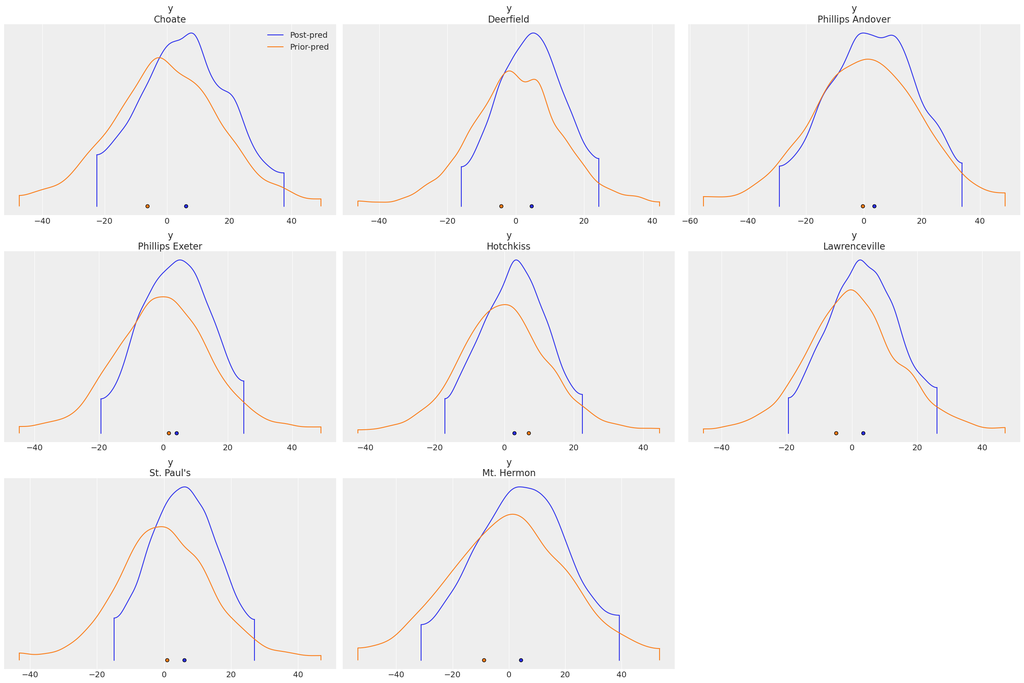

```julia
plot_density(
    [idata.posterior_predictive, idata.prior_predictive];
    data_labels=["Post-pred", "Prior-pred"],
    var_names=["y"],
)
gcf()
```

## Environment

```julia
using Pkg
Pkg.status()
```

```
      Status `~/work/ArviZ.jl/ArviZ.jl/docs/Project.toml`
  [131c737c] ArviZ v0.5.16 `~/work/ArviZ.jl/ArviZ.jl`
  [593b3428] CmdStan v6.6.0
  [31c24e10] Distributions v0.25.52
  [e30172f5] Documenter v0.27.15
  [366bfd00] DynamicPPL v0.19.1
  [c7f686f2] MCMCChains v5.1.0
  [438e738f] PyCall v1.93.1
  [d330b81b] PyPlot v2.10.0
  [754583d1] SampleChains v0.5.0
  [6d9fd711] SampleChainsDynamicHMC v0.3.4
  [8ce77f84] Soss v0.20.9
  [fce5fe82] Turing v0.21.1
  [f43a241f] Downloads
  [37e2e46d] LinearAlgebra
```

```julia
using InteractiveUtils
versioninfo()
```

```
Julia Version 1.7.2
Commit bf53498635 (2022-02-06 15:21 UTC)
Platform Info:
  OS: Linux (x86_64-pc-linux-gnu)
  CPU: Intel(R) Xeon(R) CPU E5-2673 v4 @ 2.30GHz
  WORD_SIZE: 64
  LIBM: libopenlibm
  LLVM: libLLVM-12.0.1 (ORCJIT, broadwell)
Environment:
  JULIA_CMDSTAN_HOME = /home/runner/work/ArviZ.jl/ArviZ.jl/.cmdstan//cmdstan-2.25.0/
  JULIA_NUM_THREADS = 2
```